# Pendugaan Parameter, Diagnostik Model, dan Peramalan

16 Oktober 2023

# Data

```r
library(rio)
library(ggplot2)
library(tsibble)
library(tseries)
library(MASS)
library(forecast)
library(TSA)
library(TTR)
library(aTSA)
library(graphics)
```

```r
stas1 <- import("https://raw.githubusercontent.com/akmalbasisjkusumah/MPDW/main/Data/Dataset%20Tugas%201.csv")
harga <- stas1[,-1]
periode <- seq(1:128)
stas1 <- cbind.data.frame(periode,harga)
stas <- ts(stas1$harga)
head(stas,10)
```

```
## Time Series:
## Start = 1
## End = 10
## Frequency = 1
##  [1] 7797.63 7773.26 7576.27 7420.72 7545.40 7548.22 7823.68 7761.29 7746.17
## [10] 7846.05
```

## Eksplorasi Data

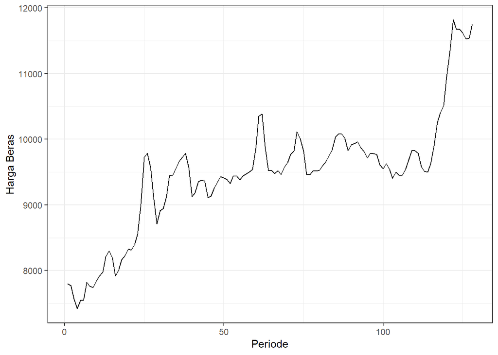

```r
plot_stas <- stas |> as_tsibble() |>
  ggplot(aes(x = stas1$periode, y = value)) + geom_line() + theme_bw() +
  xlab("Periode") + ylab("Harga Beras")
plot_stas
```

## Split Data

```r
train1 <- stas[1:118]
head(train1)
```

```
## [1] 7797.63 7773.26 7576.27 7420.72 7545.40 7548.22
```

```r
test <- stas[119:128]
head(test)
```

```
## [1] 10511.71 10954.01 11345.10 11818.17 11681.09 11672.19
```

### Eksplorasi

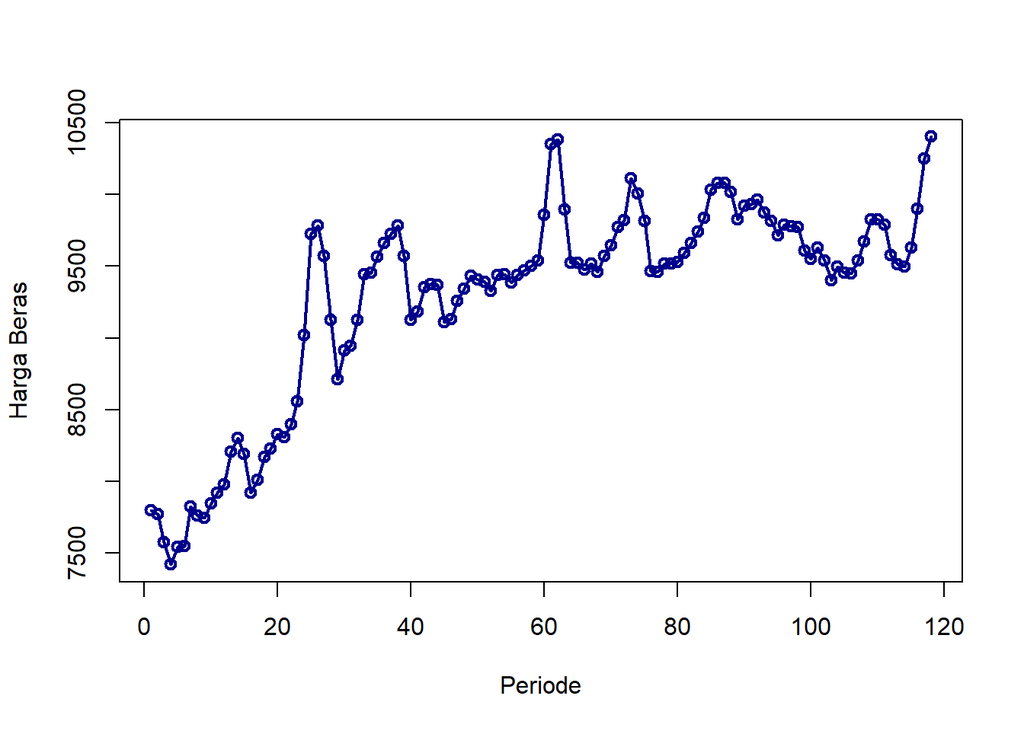

```r
#--PLOT TIME SERIES--#
plot(train1,
     col = "darkblue",
     lwd = 2,
     type = "o",
     xlab = "Periode",
     ylab = "Harga Beras")
```

Berdasarkan plot data deret waktu di atas, terlihat data tidak stasioner dalam rataan dan ragam. Data tidak stasioner dalam rataan karena tidak menyebar/bergerak di sekitar nilai tengahnya dan dikatakan tidak stasioner dalam ragam karena memiliki lebar pita yang cenderung tidak sama. Selain dengan plot data deret waktu, akan dilakukan pengecekan stasioneritas data dengan plot ACF dan uji ADF.

### Cek Stasioner

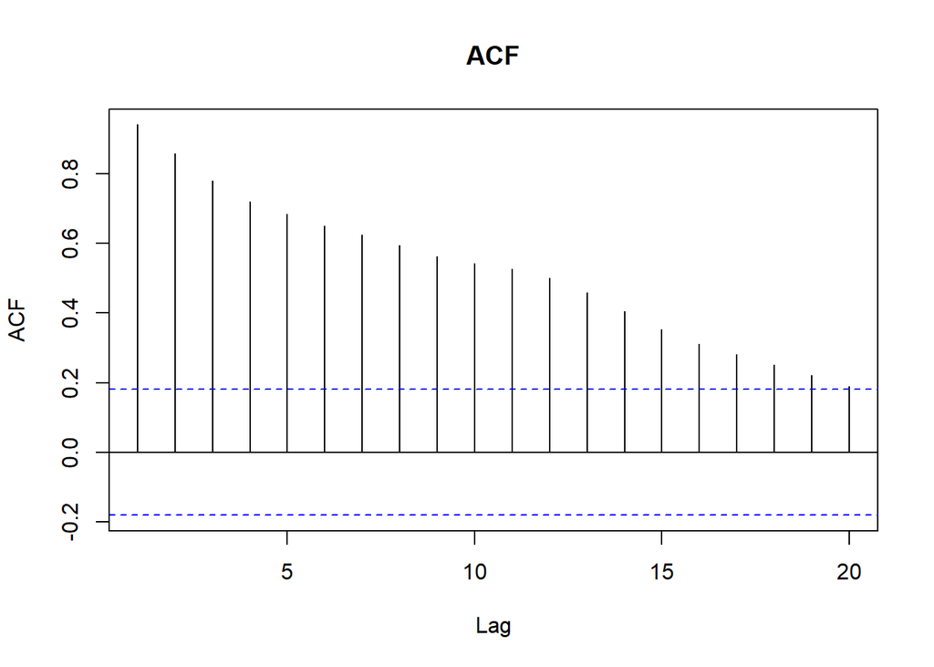

```r
acf(train1, main="ACF", lag.max=20)
```

Berdasarkan plot ACF di atas, dapat dilihat bahwa plot *tails off slowly*. Yang berarti bahwa data tersebut tidak stasioner dalam rataan.

```r
adf.test(train1)
```

```
## Augmented Dickey-Fuller Test
## alternative: stationary
##
## Type 1: no drift no trend
##      lag   ADF p.value
## [1,]   0 1.220   0.941
## [2,]   1 0.723   0.850
## [3,]   2 1.087   0.924
## [4,]   3 1.334   0.953
## [5,]   4 1.360   0.955
## Type 2: with drift no trend
##      lag   ADF p.value
## [1,]   0 -1.71   0.442
## [2,]   1 -2.41   0.168
## [3,]   2 -2.36   0.191
## [4,]   3 -2.42   0.165
## [5,]   4 -2.24   0.236
## Type 3: with drift and trend
##      lag   ADF p.value
## [1,]   0 -2.28  0.4542
## [2,]   1 -3.62  0.0346
## [3,]   2 -3.01  0.1559
## [4,]   3 -2.73  0.2700
## [5,]   4 -2.44  0.3908
## ----
## Note: in fact, p.value = 0.01 means p.value <= 0.01
```

$H_0$ : Data tidak stasioner dalam rataan

$H_1$ : Data stasioner dalam rataan

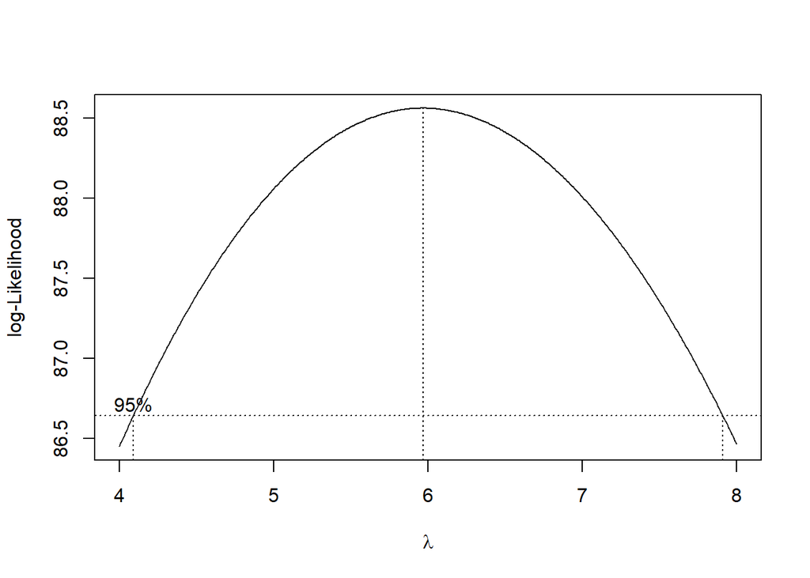

```r
index <- seq(1:118)
bc = boxcox(train1~index, lambda = seq(4,8,by=0.01))
```

```r
#Nilai Rounded Lambda
lambda <- bc$x[which.max(bc$y)]
lambda
```

```
## [1] 5.97
```

```r
#SK
bc$x[bc$y > max(bc$y) - 1/2 * qchisq(.95,1)]
```

```
##   [1] 4.10 4.11 4.12 4.13 4.14 4.15 4.16 4.17 4.18 4.19 4.20 4.21 4.22 4.23 4.24
##  [16] 4.25 4.26 4.27 4.28 4.29 4.30 4.31 4.32 4.33 4.34 4.35 4.36 4.37 4.38 4.39
##  [31] 4.40 4.41 4.42 4.43 4.44 4.45 4.46 4.47 4.48 4.49 4.50 4.51 4.52 4.53 4.54
##  [46] 4.55 4.56 4.57 4.58 4.59 4.60 4.61 4.62 4.63 4.64 4.65 4.66 4.67 4.68 4.69
##  [61] 4.70 4.71 4.72 4.73 4.74 4.75 4.76 4.77 4.78 4.79 4.80 4.81 4.82 4.83 4.84
##  [76] 4.85 4.86 4.87 4.88 4.89 4.90 4.91 4.92 4.93 4.94 4.95 4.96 4.97 4.98 4.99
##  [91] 5.00 5.01 5.02 5.03 5.04 5.05 5.06 5.07 5.08 5.09 5.10 5.11 5.12 5.13 5.14
## [106] 5.15 5.16 5.17 5.18 5.19 5.20 5.21 5.22 5.23 5.24 5.25 5.26 5.27 5.28 5.29
## [121] 5.30 5.31 5.32 5.33 5.34 5.35 5.36 5.37 5.38 5.39 5.40 5.41 5.42 5.43 5.44
## [136] 5.45 5.46 5.47 5.48 5.49 5.50 5.51 5.52 5.53 5.54 5.55 5.56 5.57 5.58 5.59
## [151] 5.60 5.61 5.62 5.63 5.64 5.65 5.66 5.67 5.68 5.69 5.70 5.71 5.72 5.73 5.74
## [166] 5.75 5.76 5.77 5.78 5.79 5.80 5.81 5.82 5.83 5.84 5.85 5.86 5.87 5.88 5.89
## [181] 5.90 5.91 5.92 5.93 5.94 5.95 5.96 5.97 5.98 5.99 6.00 6.01 6.02 6.03 6.04
## [196] 6.05 6.06 6.07 6.08 6.09 6.10 6.11 6.12 6.13 6.14 6.15 6.16 6.17 6.18 6.19
## [211] 6.20 6.21 6.22 6.23 6.24 6.25 6.26 6.27 6.28 6.29 6.30 6.31 6.32 6.33 6.34
## [226] 6.35 6.36 6.37 6.38 6.39 6.40 6.41 6.42 6.43 6.44 6.45 6.46 6.47 6.48 6.49
## [241] 6.50 6.51 6.52 6.53 6.54 6.55 6.56 6.57 6.58 6.59 6.60 6.61 6.62 6.63 6.64
## [256] 6.65 6.66 6.67 6.68 6.69 6.70 6.71 6.72 6.73 6.74 6.75 6.76 6.77 6.78 6.79
## [271] 6.80 6.81 6.82 6.83 6.84 6.85 6.86 6.87 6.88 6.89 6.90 6.91 6.92 6.93 6.94
## [286] 6.95 6.96 6.97 6.98 6.99 7.00 7.01 7.02 7.03 7.04 7.05 7.06 7.07 7.08 7.09
## [301] 7.10 7.11 7.12 7.13 7.14 7.15 7.16 7.17 7.18 7.19 7.20 7.21 7.22 7.23 7.24
## [316] 7.25 7.26 7.27 7.28 7.29 7.30 7.31 7.32 7.33 7.34 7.35 7.36 7.37 7.38 7.39
## [331] 7.40 7.41 7.42 7.43 7.44 7.45 7.46 7.47 7.48 7.49 7.50 7.51 7.52 7.53 7.54
## [346] 7.55 7.56 7.57 7.58 7.59 7.60 7.61 7.62 7.63 7.64 7.65 7.66 7.67 7.68 7.69
## [361] 7.70 7.71 7.72 7.73 7.74 7.75 7.76 7.77 7.78 7.79 7.80 7.81 7.82 7.83 7.84
## [376] 7.85 7.86 7.87 7.88 7.89 7.90 7.91
```

Gambar di atas menunjukkan nilai *rounded value* ($\lambda$) optimum sebesar **5.97** dan pada selang kepercayaan 95% nilai memiliki batas bawah **4.10** dan batas atas **7.91**. Selang tersebut tidak memuat nilai satu sehingga dapat dikatakan bahwa data tidak stasioner dalam ragam.

### Differencing

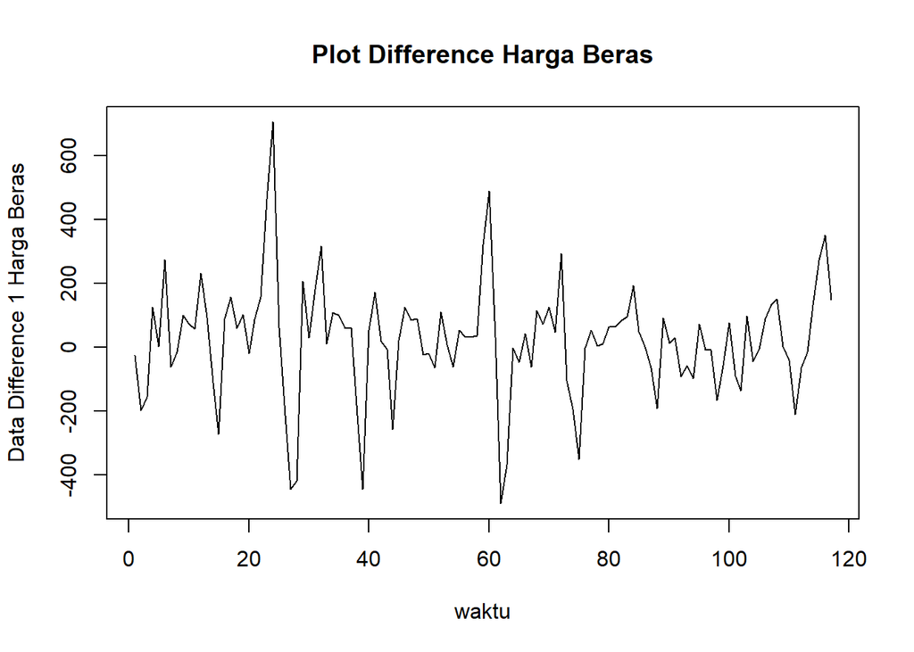

```r
train <- diff(train1,differences = 1)
plot.ts(train, lty=1, xlab="waktu", ylab="Data Difference 1 Harga Beras", main="Plot Difference Harga Beras")
```

#### Cek Stasioner

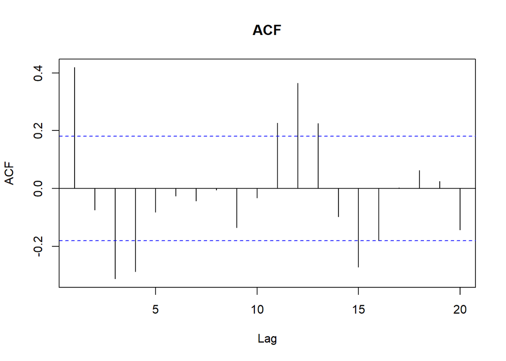

```r
acf(train, main="ACF", lag.max=20)
```

```r
adf.test(train)
```

```
## Augmented Dickey-Fuller Test
## alternative: stationary
##
## Type 1: no drift no trend
##      lag   ADF p.value
## [1,]   0 -6.75    0.01
## [2,]   1 -7.70    0.01
## [3,]   2 -7.48    0.01
## [4,]   3 -6.51    0.01
## [5,]   4 -5.25    0.01
## Type 2: with drift no trend
##      lag   ADF p.value
## [1,]   0 -6.80    0.01
## [2,]   1 -7.82    0.01
## [3,]   2 -7.67    0.01
## [4,]   3 -6.72    0.01
## [5,]   4 -5.51    0.01
## Type 3: with drift and trend
##      lag   ADF p.value
## [1,]   0 -6.78    0.01
## [2,]   1 -7.82    0.01
## [3,]   2 -7.72    0.01
## [4,]   3 -6.78    0.01
## [5,]   4 -5.62    0.01
## ----
## Note: in fact, p.value = 0.01 means p.value <= 0.01
```

$H_0$ : Data tidak stasioner dalam rataan

$H_1$ : Data stasioner dalam rataan

Berdasarkan uji ADF tersebut, didapat *p-value* sebesar 0.01 yang lebih kecil dari taraf nyata 5% sehingga tolak $H_0$ dan menandakan bahwa data stasioner dalam rataan. Hal ini sesuai dengan hasil eksplorasi menggunakan plot time series dan plot ACF.

### Spesifikasi Model

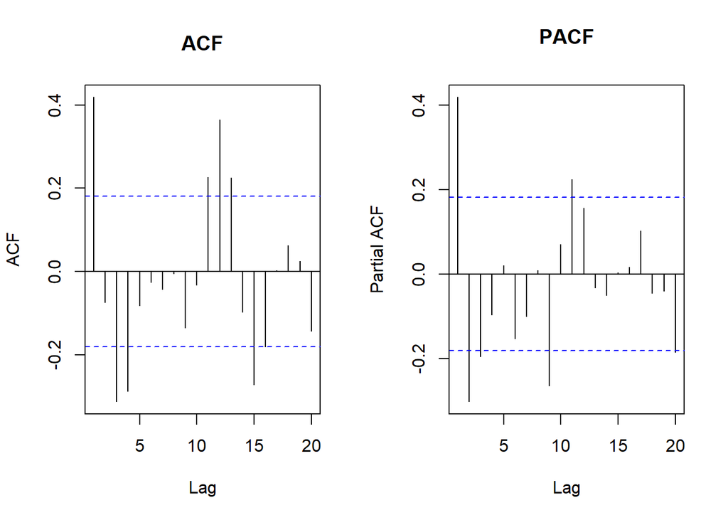

```r
par(mfrow = c(1,2))
acf(train, main="ACF", lag.max=20) #ARIMA(0,0,2)
pacf(train, main="PACF", lag.max=20) #ARIMA(1,0,0)
```

```r
par(mfrow = c(1,1))
```

Berdasarkan plot ACF terkihat model *cuts off* pada lag ketiga, sehingga didapatkan model ARIMA(0,1,3) Selanjutnya, berdasarkan plot PACF, terlihat *cuts off* pada lag kedua sehingga model yang terbentuk adalah ARIMA(2,1,0). Selain dengan plot ACF dan PACF, penentuan spesifikasi model dilakukan dengan *extended ACF* (EACF) berikut ini.

```r
eacf(train)
```

```
## AR/MA
##   0 1 2 3 4 5 6 7 8 9 10 11 12 13
## 0 x o x x o o o o o o x  x  x  o
## 1 x o x x o o o o o o o  x  x  o
## 2 x o o x o o o o o o o  o  o  o
## 3 x o o x o o o o o o o  o  o  o
## 4 o o x o o o o o o o o  o  o  o
## 5 o x x o o o o o o o o  o  o  o
## 6 x x x o o o o o o o o  o  o  o
## 7 o o x o o o o x o o o  o  o  o
```

Menggunakan plot EACF, dapat diambil beberapa model dengan melihat ujung segitiga yang terbentuk, antara lain ARIMA(0,1,1), ARIMA(1,1,1), ARIMA(2,1,1), ARIMA(2,1,2), ARIMA(3,1,1), dan ARIMA(3,1,2).

### Pendugaan Parameter

```r
model1.train=Arima(train, order=c(0,1,3),method="ML")
summary(model1.train) #AIC=1514.14
```

```
## Series: train
## ARIMA(0,1,3)
##
## Coefficients:
##           ma1      ma2      ma3
##       -0.4575  -0.4031  -0.1394
## s.e.   0.0937   0.1099   0.1122
##
## sigma^2 = 25276:  log likelihood = -753.07
## AIC=1514.14   AICc=1514.5   BIC=1525.16
##
## Training set error measures:
##                     ME     RMSE      MAE      MPE     MAPE      MASE
## Training set -1.315361 156.2429 118.5326 -147.406 332.8718 0.8370103
##                     ACF1
## Training set -0.01060552
```

```r
lmtest::coeftest(model1.train) #ma 3 tidak signifikan
```

```
##
## z test of coefficients:
##
##      Estimate Std. Error z value  Pr(>|z|)
## ma1 -0.457501   0.093682 -4.8836 1.042e-06 ***
## ma2 -0.403071   0.109918 -3.6670 0.0002454 ***
## ma3 -0.139423   0.112199 -1.2426 0.2140017
## ---
## Signif. codes:  0 '***' 0.001 '**' 0.01 '*' 0.05 '.' 0.1 ' ' 1
```

```r
model2.train=Arima(train, order=c(2,1,0),method="ML")
summary(model2.train) #AIC=1547.11
```

```
## Series: train
## ARIMA(2,1,0)
##
## Coefficients:
##           ar1      ar2
##       -0.1038  -0.2249
## s.e.   0.0909   0.0904
##
## sigma^2 = 35030:  log likelihood = -770.55
## AIC=1547.11   AICc=1547.32   BIC=1555.37
##
## Training set error measures:
##                    ME    RMSE      MAE       MPE     MAPE      MASE        ACF1
## Training set 2.458574 184.749 138.1039 -368.9166 605.8573 0.9752123 -0.06301916
```

```r
lmtest::coeftest(model2.train) #ar 1 tidak signifikan
```

```
##
## z test of coefficients:
##
##      Estimate Std. Error z value Pr(>|z|)
## ar1 -0.103768   0.090904 -1.1415  0.25366
## ar2 -0.224920   0.090387 -2.4884  0.01283 *
## ---
## Signif. codes:  0 '***' 0.001 '**' 0.01 '*' 0.05 '.' 0.1 ' ' 1
```

```r
model3.train=Arima(train, order=c(1,1,1),method="ML")
summary(model3.train) #AIC=1518.37
```

```
## Series: train
## ARIMA(1,1,1)
##
## Coefficients:
##          ar1      ma1
##       0.4292  -1.0000
## s.e.  0.0848   0.0231
##
## sigma^2 = 26474:  log likelihood = -756.18
## AIC=1518.37   AICc=1518.58   BIC=1526.63
##
## Training set error measures:
##                       ME     RMSE      MAE       MPE     MAPE      MASE
## Training set -0.05238508 160.6099 119.5303 -163.0375 347.7154 0.8440556
##                   ACF1
## Training set 0.1194168
```

```r
lmtest::coeftest(model3.train) #Seluruh parameter signifikan
```

```
##
## z test of coefficients:
##
##      Estimate Std. Error  z value  Pr(>|z|)
## ar1  0.429182   0.084833   5.0591 4.212e-07 ***
## ma1 -1.000000   0.023066 -43.3542 < 2.2e-16 ***
## ---
## Signif. codes:  0 '***' 0.001 '**' 0.01 '*' 0.05 '.' 0.1 ' ' 1
```

```r
model4.train=Arima(train, order=c(0,1,1),method="ML")
summary(model4.train) #AIC=1550.09
```

```
## Series: train
## ARIMA(0,1,1)
##
## Coefficients:
##           ma1
##       -0.2235
## s.e.   0.1981
##
## sigma^2 = 36268:  log likelihood = -773.04
## AIC=1550.09   AICc=1550.2   BIC=1555.6
##
## Training set error measures:
##                    ME     RMSE      MAE       MPE     MAPE     MASE       ACF1
## Training set 2.403494 188.8075 137.4788 -455.5916 673.5421 0.970798 0.07372143
```

```r
lmtest::coeftest(model4.train) #tidak signifikan
```

```
##
## z test of coefficients:
##
##     Estimate Std. Error z value Pr(>|z|)
## ma1 -0.22347    0.19805 -1.1283   0.2592
```

```r
model5.train=Arima(train, order=c(2,1,1),method="ML")
summary(model5.train) #AIC=1509.94
```

```
## Series: train
## ARIMA(2,1,1)
##
## Coefficients:
##          ar1      ar2      ma1
##       0.5478  -0.2980  -1.0000
## s.e.  0.0884   0.0898   0.0266
##
## sigma^2 = 24263:  log likelihood = -750.97
## AIC=1509.94   AICc=1510.3   BIC=1520.95
##
## Training set error measures:
##                     ME     RMSE      MAE       MPE     MAPE      MASE
## Training set -3.541494 153.0794 116.1704 -81.22543 280.1211 0.8203299
##                     ACF1
## Training set -0.06279381
```

```r
lmtest::coeftest(model5.train) #seluruh parameter signifikan
```

```
##
## z test of coefficients:
##
##      Estimate Std. Error  z value  Pr(>|z|)
## ar1  0.547793   0.088382   6.1980 5.719e-10 ***
## ar2 -0.297967   0.089792  -3.3184 0.0009053 ***
## ma1 -0.999995   0.026598 -37.5962 < 2.2e-16 ***
## ---
## Signif. codes:  0 '***' 0.001 '**' 0.01 '*' 0.05 '.' 0.1 ' ' 1
```

```r
model6.train=Arima(train, order=c(2,1,2),method="ML")
summary(model6.train) #AIC=1504.79
```

```
## Series: train
## ARIMA(2,1,2)
##
## Coefficients:
##          ar1      ar2      ma1     ma2
##       1.1525  -0.5613  -1.7000  0.7094
## s.e.  0.1246   0.0814   0.1317  0.1326
##
## sigma^2 = 23108:  log likelihood = -747.4
## AIC=1504.79   AICc=1505.34   BIC=1518.56
##
## Training set error measures:
##                     ME     RMSE      MAE       MPE     MAPE      MASE
## Training set -7.377822 148.7291 113.4869 -123.3976 365.7157 0.8013808
##                      ACF1
## Training set -0.003257359
```

```r
lmtest::coeftest(model6.train) #seluruh parameter signifikan
```

```
##
## z test of coefficients:
##
##      Estimate Std. Error  z value  Pr(>|z|)
## ar1  1.152510   0.124630   9.2475 < 2.2e-16 ***
## ar2 -0.561335   0.081382  -6.8975 5.292e-12 ***
## ma1 -1.700036   0.131747 -12.9038 < 2.2e-16 ***
## ma2  0.709415   0.132629   5.3489 8.851e-08 ***
## ---
## Signif. codes:  0 '***' 0.001 '**' 0.01 '*' 0.05 '.' 0.1 ' ' 1
```

```r
model7.train=Arima(train, order=c(3,1,1),method="ML")
summary(model7.train) #AIC=1507.35
```

```
## Series: train
## ARIMA(3,1,1)
##
## Coefficients:
##          ar1      ar2      ar3      ma1
##       0.4865  -0.1952  -0.2001  -1.0000
## s.e.  0.0907   0.0998   0.0922   0.0352
##
## sigma^2 = 23428:  log likelihood = -748.68
## AIC=1507.35   AICc=1507.9   BIC=1521.12
##
## Training set error measures:
##                    ME     RMSE      MAE      MPE     MAPE      MASE        ACF1
## Training set -6.83971 149.7556 114.7874 -112.598 308.8696 0.8105638 -0.02779297
```

```r
lmtest::coeftest(model7.train) #ar 2 tidak signifikan
```

```
##
## z test of coefficients:
##
##      Estimate Std. Error  z value  Pr(>|z|)
## ar1  0.486459   0.090735   5.3613 8.262e-08 ***
## ar2 -0.195199   0.099779  -1.9563   0.05043 .
## ar3 -0.200075   0.092189  -2.1703   0.02999 *
## ma1 -1.000000   0.035233 -28.3828 < 2.2e-16 ***
## ---
## Signif. codes:  0 '***' 0.001 '**' 0.01 '*' 0.05 '.' 0.1 ' ' 1
```

```r
model8.train=Arima(train, order=c(3,1,2),method="ML")
summary(model8.train) #AIC=1506.77
```

```
## Series: train
## ARIMA(3,1,2)
##
## Coefficients:
##          ar1      ar2     ar3      ma1     ma2
##       1.1746  -0.5830  0.0181  -1.7169  0.7261
## s.e.  0.1877   0.1689  0.1248   0.1626  0.1622
##
## sigma^2 = 23314:  log likelihood = -747.38
## AIC=1506.77   AICc=1507.54   BIC=1523.29
##
## Training set error measures:
##                     ME     RMSE     MAE       MPE     MAPE      MASE
## Training set -7.215798 148.7223 113.492 -119.8776 362.4491 0.8014169
##                      ACF1
## Training set -0.008866752
```

```r
lmtest::coeftest(model8.train) #ar3 tidak signifikan
```

```
##
## z test of coefficients:
##
##      Estimate Std. Error  z value  Pr(>|z|)
## ar1  1.174645   0.187696   6.2582 3.894e-10 ***
## ar2 -0.583010   0.168907  -3.4517 0.0005571 ***
## ar3  0.018111   0.124815   0.1451 0.8846313
## ma1 -1.716878   0.162625 -10.5573 < 2.2e-16 ***
## ma2  0.726085   0.162199   4.4765 7.588e-06 ***
## ---
## Signif. codes:  0 '***' 0.001 '**' 0.01 '*' 0.05 '.' 0.1 ' ' 1
```

```r
#model yang dipilih adalah model6, yaitu ARIMA(2,1,2)
```

Berdasarkan pendugaan parameter di atas, nilai AIC terkecil dimiliki oleh model ARIMA(2,1,2) dan parameter model ARIMA(2,1,2) juga seluruhnya signifikan sehingga model yang dipilih adalah model ARIMA(2,1,2).